# Act Report

### Insight #2: What is the average rating of these popular dog breed:

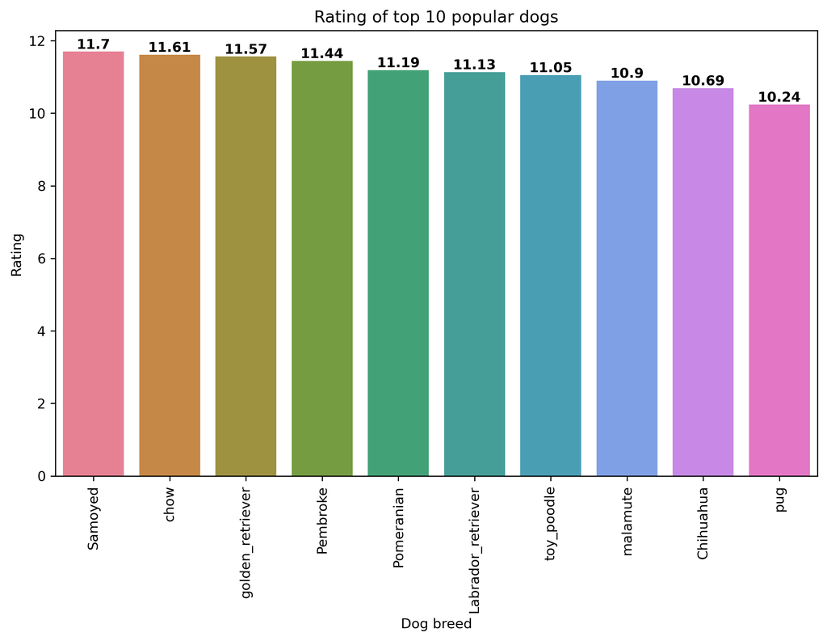

```python
image_path = 'Result_2.png'
# Display the image
Image(filename=image_path)
```

I wanted to measure the top 10 highest rating among all the breed, however there case where the breed was only mentioned 1 and receive ridiculious rating so it became inacurate to analyze, therefore i chose to measure the popularity of the most popular dog, given that they are mentioned many time so the rating will be more appropriate. Among the most popular dog, it seems like Samoyed received the highest rating, at an average of 11.7 while pug was the least favourite with a point of 10.24

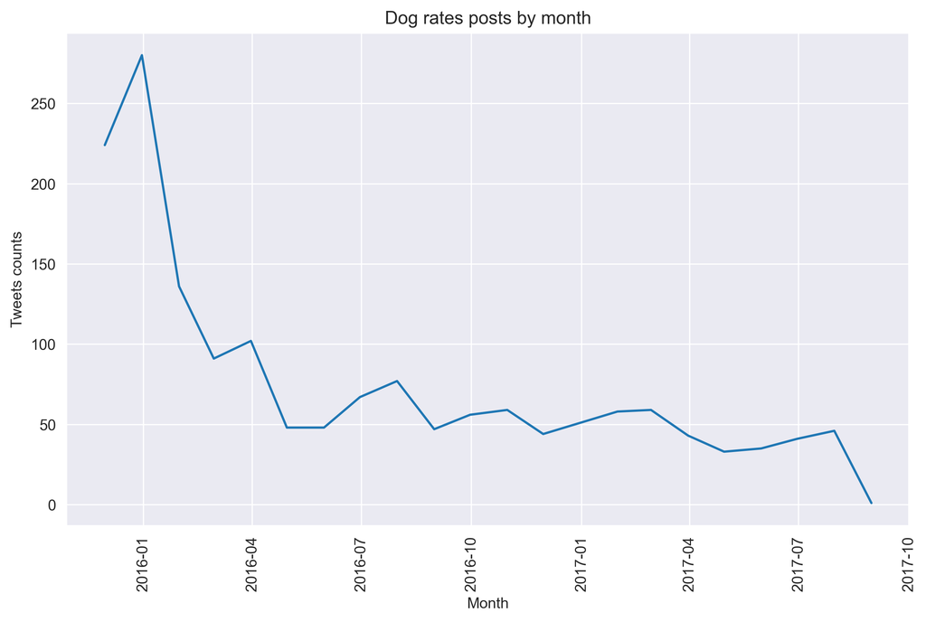

```python
image_path = 'Result_3.png'
# Display the image
Image(filename=image_path)
```